# Introduction Exploring Data with R

NZSA/ORSNZ 2016

## SETUP

- Point your web browser to https://github.com/dicook/NZSAORSNZ16_workshop
- Download the repo, using "Download ZIP"
- OR
- If web is NOT WORKING there will be a copy of the zip file on the H: drive on your computer. Copy this into the "Downloads" directory

## WORKING DIRECTORY

- Unzip the files
- Open RStudio
- Create a new PROJECT in the directory where the workshop files are

## GETTING STARTED

- Open the "index.Rmd" file in the "1-intro" folder
- Click "KnitHTML", which will compile the file into the slides

## SLIDES

You can follow along with the slides by opening the "index.html" file. It will open in your web browser.

## Outline

- Session 1: How to think about data, and getting started plotting with the grammar of graphics
- Session 2: Wrangling data into shape, useful practices, cognitive perception
- Session 3: Advanced graphics, layering, using maps

## About R?

- **"R has become the most popular language for data science and an essential tool for Finance and analytics-driven companies such as Google, Facebook, and LinkedIn."** [Microsoft 2015](http://www.revolutionanalytics.com/what-r)
- Top 5 programming languages according to IEEE
- There are now 9605 contributed packages

## Relationship between R and RStudio

[From Julie Lowndes](http://jules32.github.io/resources/RStudio_intro/):

If R were an airplane, RStudio would be the airport, providing many, many supporting services that make it easier for you, the pilot, to take off and go to awesome places. Sure, you can fly an airplane without an airport, but having those runways and supporting infrastructure is a game-changer.

## The RStudio IDE

- Source editor: (1) Docking station for multiple files, (2) Useful shortcuts ("Knit"), (3) Highlighting/Tab-completion, (4) Code-checking (R, HTML, JS), (5) Debugging features
- Console window: (1) Highlighting/Tab-completion, (2) Search recent commands
- Other tabs/panes: (1) Graphics, (2) R documentation, (3) Environment pane, (4) File system navigation/access, (5) Tools for package development, git, etc

## These Slides

- This is a "live" document
- Code and explanations together
- Run the software to make the calculations on the data, and produce nice presentation, or Word or pdf or html document
- I recommend working this way on all your projects
- Its also great for teaching. I have students to submit reports, both the Word file and the Rmd

## What is R Markdown?

- From the [R Markdown home page](http://rmarkdown.rstudio.com/):

R Markdown is an authoring format that enables easy creation of dynamic documents, presentations, and reports from R. It combines the core syntax of **markdown** (an easy-to-write plain text format) **with embedded R code chunks** that are run so their output can be included in the final document. R Markdown documents are fully reproducible (they can be automatically regenerated whenever underlying R code or data changes).

## Your Turn

Let's look at the rmarkdown syntax:

- How does markdown know that the line is code?
- Name the code chunk option which sets the size of the plot
- The opening lines in the document are called yaml, and specify title, author, date, type of output, …
- What is the markdown syntax indicating a slide title?

## Operations

- The entire document can be "knitted"
- While developing run code chunk by chunk
- You can also run line by line, but you need ot be sure that your console window points to the same directory as the Rmd file

## RStudio Cheatsheets

- https://www.rstudio.com/resources/cheatsheets/
  - RStudio IDE
  - RMarkdown
  - Data visualisation with ggplot2
  - Data wrangling with tidyr and dplyr
- Also see [Garret Grolemund's list of software](https://github.com/rstudio/RStartHere)

## Getting data

Data can be found in R packages

```r
data(economics, package = "ggplot2")
# data frames are essentially a list of vectors
str(economics)
```

```
#> Classes 'tbl_df', 'tbl' and 'data.frame':    574 obs. of  6 variables:
#>  $ date    : Date, format: "1967-07-01" "1967-08-01" ...
#>  $ pce     : num  507 510 516 513 518 ...
#>  $ pop     : int  198712 198911 199113 199311 199498 199657 199808 199920 200056 200208 ...
#>  $ psavert : num  12.5 12.5 11.7 12.5 12.5 12.1 11.7 12.2 11.6 12.2 ...
#>  $ uempmed : num  4.5 4.7 4.6 4.9 4.7 4.8 5.1 4.5 4.1 4.6 ...
#>  $ unemploy: int  2944 2945 2958 3143 3066 3018 2878 3001 2877 2709 ...
```

These are not usually kept up to date but are good for practicing your analysis skills on.

## Getting Data

Or in their own packages

```r
library(gapminder)
str(gapminder)
```

```
#> Classes 'tbl_df', 'tbl' and 'data.frame':    1704 obs. of  6 variables:
#>  $ country  : Factor w/ 142 levels "Afghanistan",..: 1 1 1 1 1 1 1 1 1 1 ...
#>  $ continent: Factor w/ 5 levels "Africa","Americas",..: 3 3 3 3 3 3 3 3 3 3 ...
#>  $ year     : int  1952 1957 1962 1967 1972 1977 1982 1987 1992 1997 ...
#>  $ lifeExp  : num  28.8 30.3 32 34 36.1 ...
#>  $ pop      : int  8425333 9240934 10267083 11537966 13079460 14880372 12881816 13867957 16317921 22227415 ...
#>  $ gdpPercap: num  779 821 853 836 740 ...
```

More contemporary sets here, but not updated frequently.

## Getting Data

```r
ped <- read_csv("../data/Pedestrian_Counts.csv")
kable(head(ped))
```

| Date_Time | Sensor_ID | Sensor_Name | Hourly_Counts |
| --- | --- | --- | --- |
| 01-MAY-2009 00:00 | 4 | Town Hall (West) | 209 |
| 01-MAY-2009 00:00 | 17 | Collins Place (South) | 28 |
| 01-MAY-2009 00:00 | 18 | Collins Place (North) | 36 |
| 01-MAY-2009 00:00 | 16 | Australia on Collins | 22 |
| 01-MAY-2009 00:00 | 2 | Bourke Street Mall (South) | 52 |
| 01-MAY-2009 00:00 | 1 | Bourke Street Mall (North) | 53 |

Pulling data together yourself, or compiled by someone else.

## Your Turn

- Create a new `Rmd` file for the Your Turns in the workshop

## Your Turn

- Look at the documentation for `economics` data in the `ggplot2` package.
- Think of 3 questions you could answer using these variables?
- Write these into your `.Rmd` file.

## Your Turn

- Read the documentation for `gapminder` data.
- Think of 3 questions you could answer using these variables?
- Write these into your `.Rmd` file.

## Your Turn

- Take a look at the `PISA` data, by looking at the `student_codebook.pdf` document. (Full details can be found at [http://www.oecd.org/pisa/pisaproducts/](http://www.oecd.org/pisa/pisaproducts/database-cbapisa2012.htm))
- Think of 3 questions you could answer using these variables?
- Write these into your `.Rmd` file.

```r
student <- readRDS("../data/student_sub.rds")
str(student)
```

```
#> 'data.frame':    271323 obs. of  50 variables:
#>  $ CNT       : chr  "ARE" "ARE" "ARE" "ARE" ...
#>  $ SCHOOLID  : num  1 1 1 1 1 1 1 1 1 1 ...
#>  $ ST04Q01   : num  2 2 2 2 2 2 2 2 2 2 ...
#>  $ ST06Q01   : num  6 8 9999 7 8 ...
#>  $ ST57Q01   : num  9997 9999 9998 9999 9997 ...
#>  $ ST57Q02   : num  9997 9999 9998 9999 9997 ...
#>  $ ST57Q03   : num  9997 9999 9998 9999 9997 ...
#>  $ ST57Q04   : num  9997 9999 9998 9999 9997 ...
#>  $ ST57Q05   : num  9997 9999 9998 9999 9997 ...
#>  $ ST57Q06   : num  9997 9999 9998 9999 9997 ...
#>  $ ST11Q01   : num  1 9 1 9 1 1 1 1 1 1 ...
#>  $ ST11Q02   : num  1 9 1 9 9 2 1 1 1 1 ...
#>  $ ST15Q01   : num  4 4 4 4 4 3 1 4 1 1 ...
#>  $ ST19Q01   : num  1 3 2 1 4 3 1 1 1 1 ...
```

[output cut: 36 more lines]

## Getting Help on the Web

- Reading documentation only gets you so far. What about *finding* function(s) and/or package(s) to help solve a problem???
- Google! (I usually prefix "CRAN" to my search; others might suggest http://www.rseek.org/
- Ask your question on a relevant StackExchange outlet such as http://stackoverflow.com/ or http://stats.stackexchange.com/
- It's becoming more and more popular to bundle "vignettes" with a package (**dplyr** has *awesome* vignettes)

```r
browseVignettes("dplyr")
```

## GRAMMAR

- The grammar of graphics makes the mapping of a data variable to a plot element explicit.
- This is a HUGE ADVANCE in data visualisation.
- This provides a closer connection between data, plots and models.
- Enables functional definition of a plot, along the lines of any other type of statistic

## Using the Package `ggplot2`

Elements of a plot

- data
- aesthetics: mapping of variables to graphical elements
- geom: type of plot structure to use
- transformations: log scale, …

Additional components

- layers: multiple geoms, multiple data sets, annotation
- facets: show subsets in different plots
- themes: modifying style

## Economics

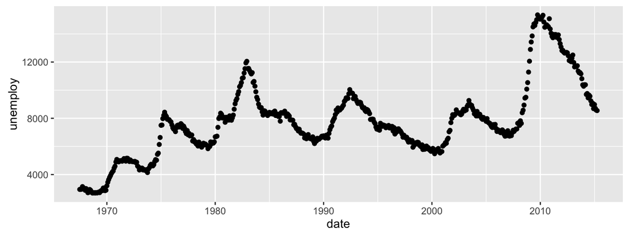

```r
ggplot(economics, aes(x=date, y=unemploy)) + geom_point()
```

## Mappings

- date is mapped to position along the x axis
- unemploy is mapped to position along the y axis
- geom_point() is used for the graphical element

## add geom_line

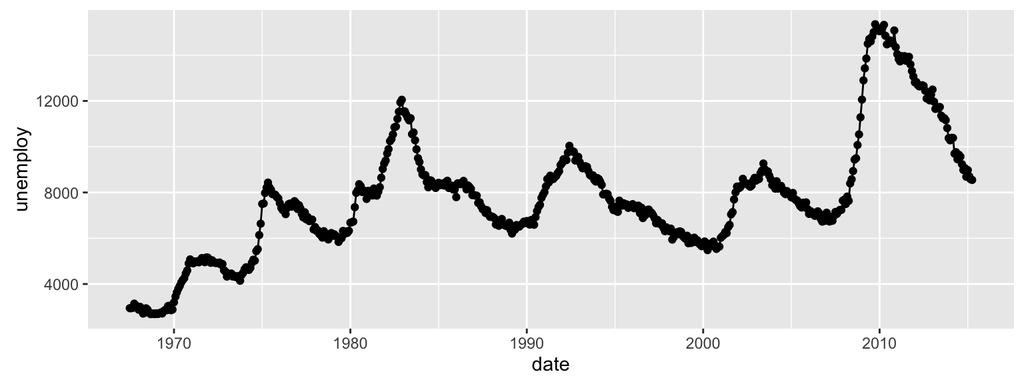

```r
ggplot(economics, aes(x=date, y=unemploy)) +
  geom_point() +
  geom_line()
```

## change axis labels

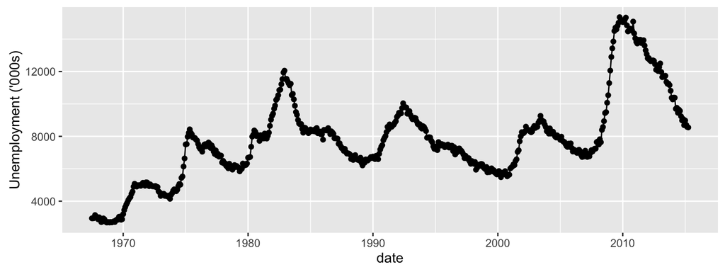

```r
ggplot(economics, aes(x=date, y=unemploy)) +
  geom_point() +
  geom_line() +
  ylab("Unemployment ('000s)")
```

## Scatterplot

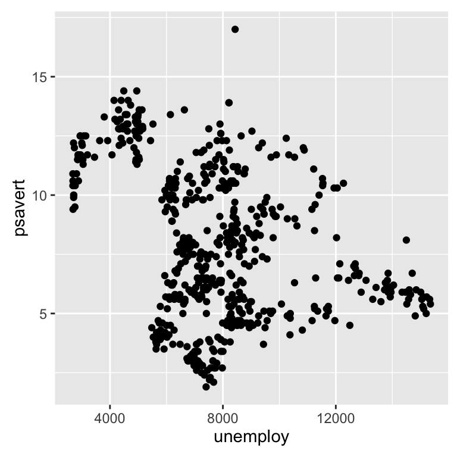

```r
ggplot(economics, aes(x=unemploy, y=psavert)) +
  geom_point() +
  theme(aspect.ratio=1)
```

## Linear fit

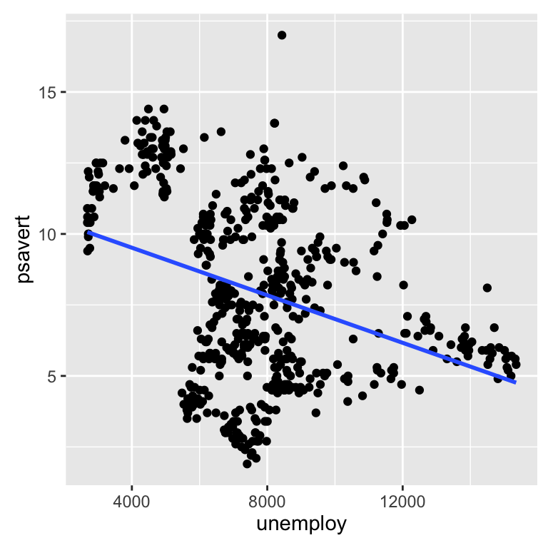

```r
ggplot(economics, aes(x=unemploy, y=psavert)) +
  geom_point() +
  theme(aspect.ratio=1) +
  geom_smooth(method="lm", se=F)
```

## Gapminder

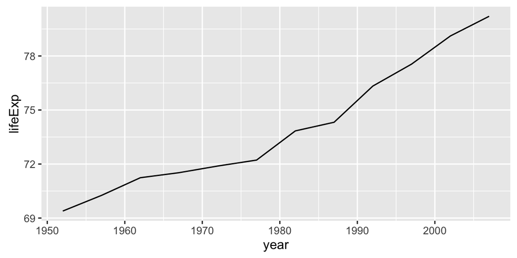

```r
nz <- gapminder %>% filter(country == "New Zealand")
ggplot(nz, aes(x=year, y=lifeExp)) + geom_line()
```

## all the countries

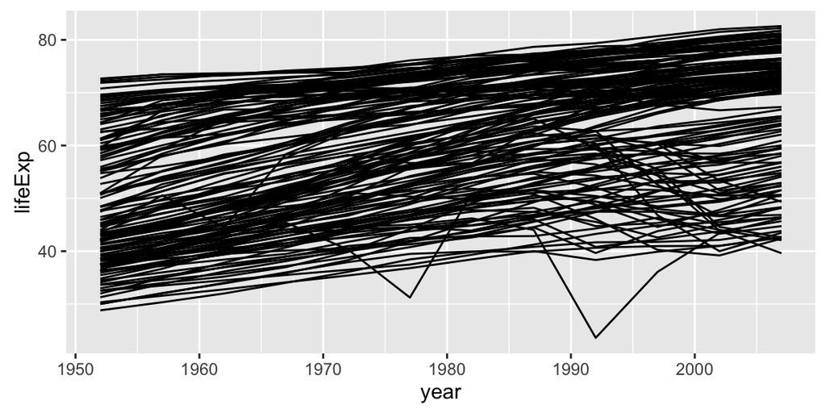

```r
ggplot(gapminder, aes(x=year, y=lifeExp, group=country)) +
  geom_line()
```

## colour by continent

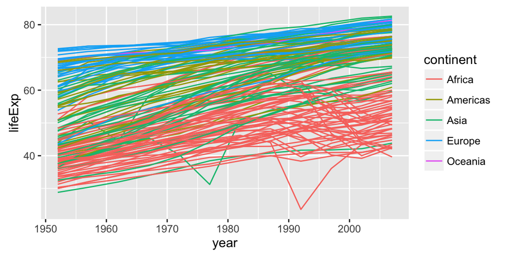

```r
ggplot(gapminder, aes(x=year, y=lifeExp,
                      group=country, colour=continent)) +
  geom_line()
```

## separately by continent

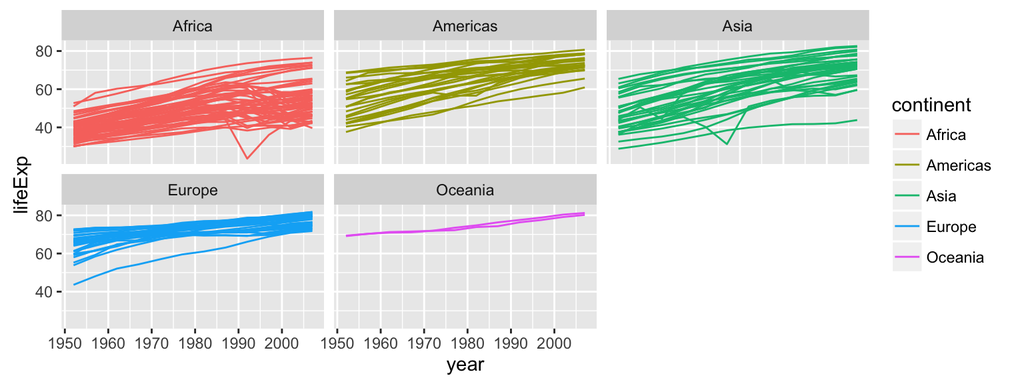

```r
ggplot(gapminder, aes(x=year, y=lifeExp,
                      group=country, colour=continent)) +
  geom_line() +
  facet_wrap(~continent, ncol=3)
```

## Type of variable suggests mapping

- The values of **quantitative** variables should be mapped to **position along a line**, e.g. histogram, scatterplot. Mapping them to colour will yield only rough return of information to the reader.
- Categorical variables could be mapped to
  - colour, if there are few categories,
  - aggregated and mapped to position along the line,
  - mapped to angle, if all categories are available.
- Order is important, and if no natural order available then impose one e.g. using count

## Categorical variables

The social variables of the PISA data include internet usage. This is a subset.

```r
internet <- read_csv("../data/internet.csv")
dim(internet)
```

```
#> [1] 37904    20
```

```r
colnames(internet)
```

```
#>  [1] "name"                         "SCHOOLID"
#>  [3] "Gender"                       "One player games"
#>  [5] "Collaborative games"          "Use email"
#>  [7] "Chat on line"                 "Social networks"
#>  [9] "Browse the Internet for fun"  "Read news"
#> [11] "Obtain practical information" "Download music"
#> [13] "Upload content"               "Internet for school"
#> [15] "Email students"               "Email teachers"
#> [17] "Download from School"         "Announcements"
#> [19] "Homework"                     "Share school material"
```

## barchart

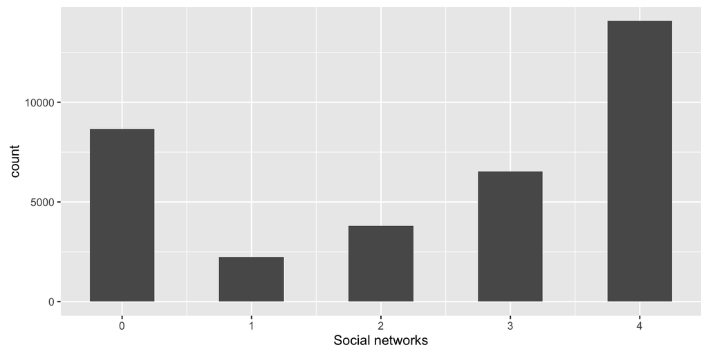

```r
ggplot(data=internet, aes(x=`Social networks`)) +
  geom_bar(binwidth=0.5)
```

Simpson's paradox may be in play when there are multiple categorical variables. Need to divide it into basic elements.

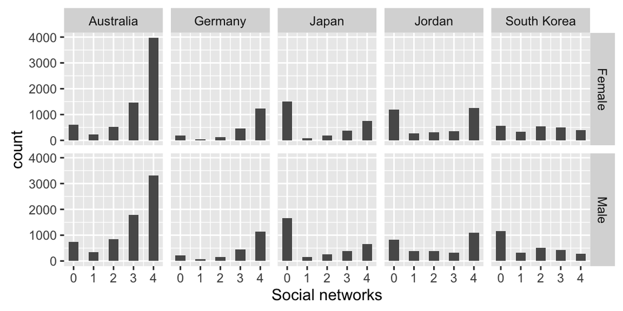

```r
ggplot(data=internet, aes(x=`Social networks`)) +
  geom_bar(binwidth=0.5) +
  facet_grid(Gender~name)
```

## stacked barchart

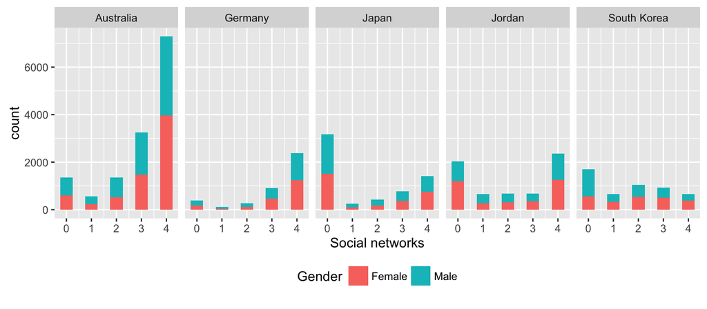

```r
ggplot(data=internet, aes(x=`Social networks`, fill=Gender)) +
  geom_bar(binwidth=0.5) +
  facet_wrap(~name, ncol=5) + theme(legend.position="bottom")
```

## dodged bars

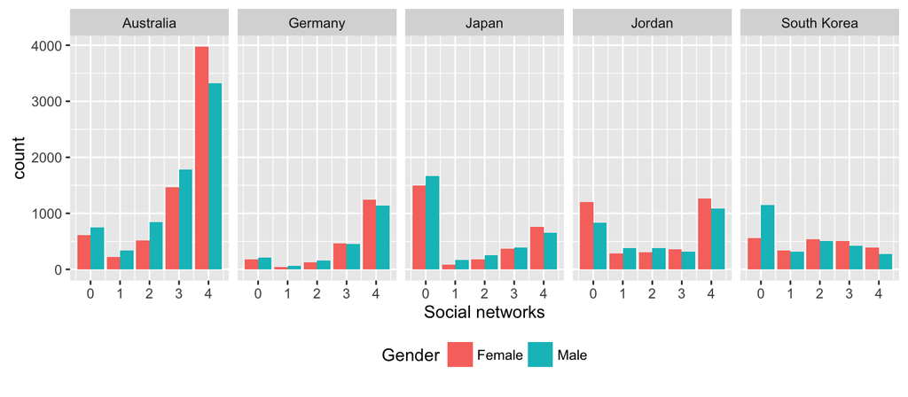

```r
ggplot(data=internet) +
  geom_bar(aes(x=`Social networks`, fill=Gender),
          position="dodge") +
  facet_wrap(~name, ncol=5) +
  theme(legend.position="bottom")
```

## piechart

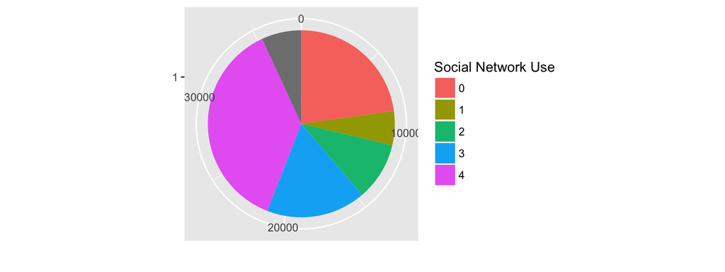

```r
ggplot(data=internet, aes(x=factor(1), fill=factor(`Social networks`))) +
  geom_bar(width = 1) + scale_x_discrete("") +
  scale_y_continuous("") +
  scale_fill_hue("Social Network Use") +
  coord_polar(theta = "y")
```

Yes, its deliberately made hard to do !

## Quantitative and categorical

```r
grad <- read_csv("../data/graduate-programs.csv")
dim(grad)
```

```
#> [1] 412  16
```

```r
colnames(grad)
```

```
#>  [1] "subject"            "Inst"               "AvNumPubs"
#>  [4] "AvNumCits"          "PctFacGrants"       "PctCompletion"
#>  [7] "MedianTimetoDegree" "PctMinorityFac"     "PctFemaleFac"
#> [10] "PctFemaleStud"      "PctIntlStud"        "AvNumPhDs"
#> [13] "AvGREs"             "TotFac"             "PctAsstProf"
#> [16] "NumStud"
```

## side-by-side boxplots

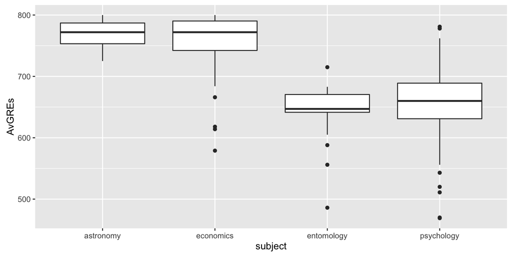

```r
ggplot(data=grad, aes(x=subject, y=AvGREs)) +
  geom_boxplot()
```

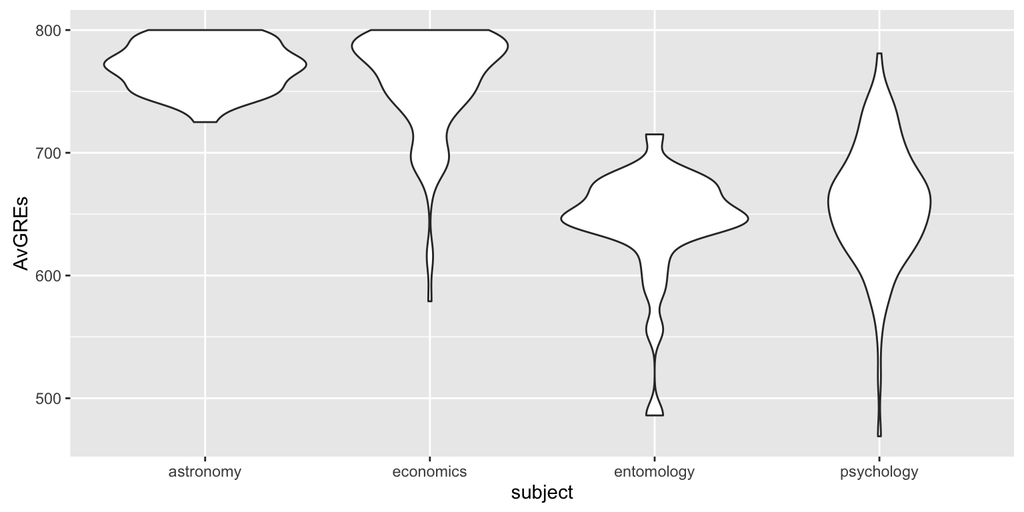

```r
ggplot(data=grad, aes(x=subject, y=AvGREs)) +
  geom_violin()
```

## Your Turn

- Create a side-by-side boxplot of average number of publications by program
- Then answer, "how do the four programs compare in terms of average number of publications?"

## Next session

- Wrangling your data into shape,
- Useful graphics, cognitive perception

## Credits

Notes prepared by Di Cook, building on joint workshops with Carson Sievert, Heike Hofmann, Eric Hare, Hadley Wickham.

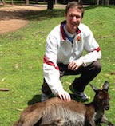

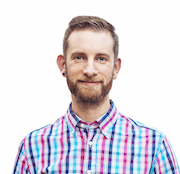

This work is licensed under a [Creative Commons Attribution-ShareAlike 4.0 International License](http://creativecommons.org/licenses/by-sa/4.0/).